# Analysis of Naomi’s data by Juliette. Influence of the tank on Betta’s behaviour.

It might be just interesting to say that fish use different places to rest, not only one type. It is particularly visible in Large where fish use all types of resting places.

**Foraging**

**Distribution**

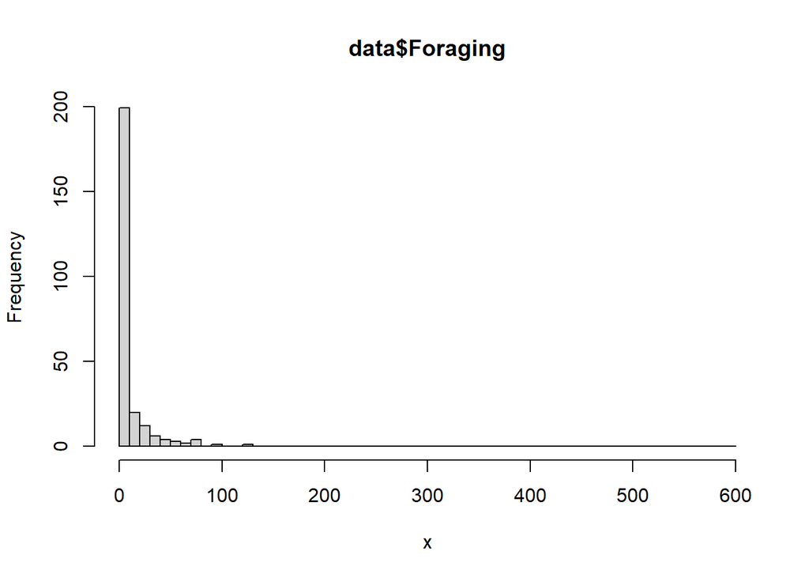

```r
hist1(data$Foraging)
```

```r
table(data$Foraging==0)
```

```
FALSE  TRUE
   84   168
```

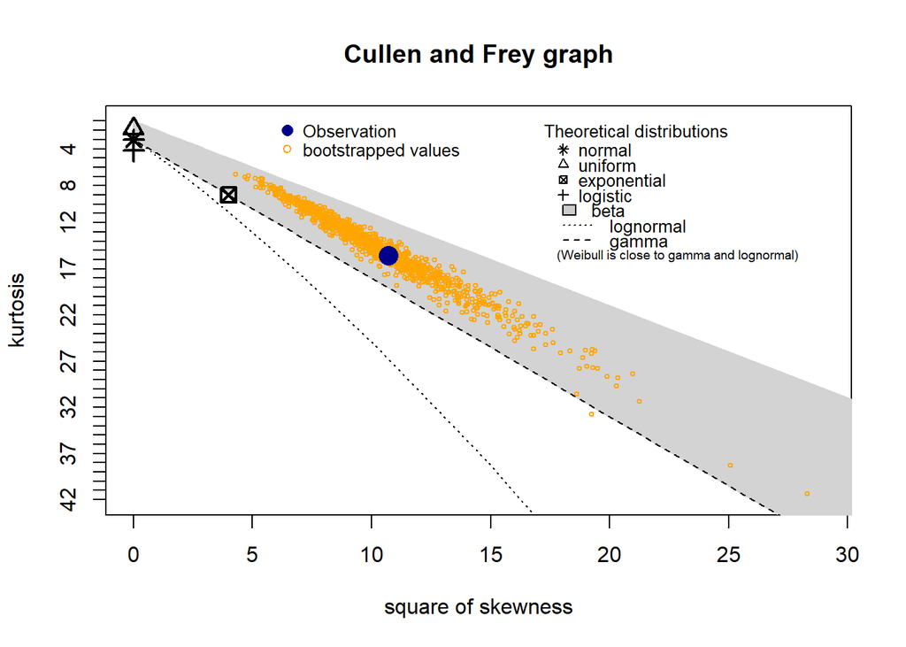

```r
descdist(data$Foraging, boot = 1000, print = FALSE)
```

The data are clearly not following a normal distribution. It seems that they could possibly follow a beta distribution but I thought beta distributions were when the variable is between 0 and 1. I decided therefore to analyse Foraging in binary: 1 if fish spent time foraging during this trial, 0 otherwise.

**Plot**

The plots are in count of trials. Green represents trials in which the fish foraged, gray in which the fish did not forage.

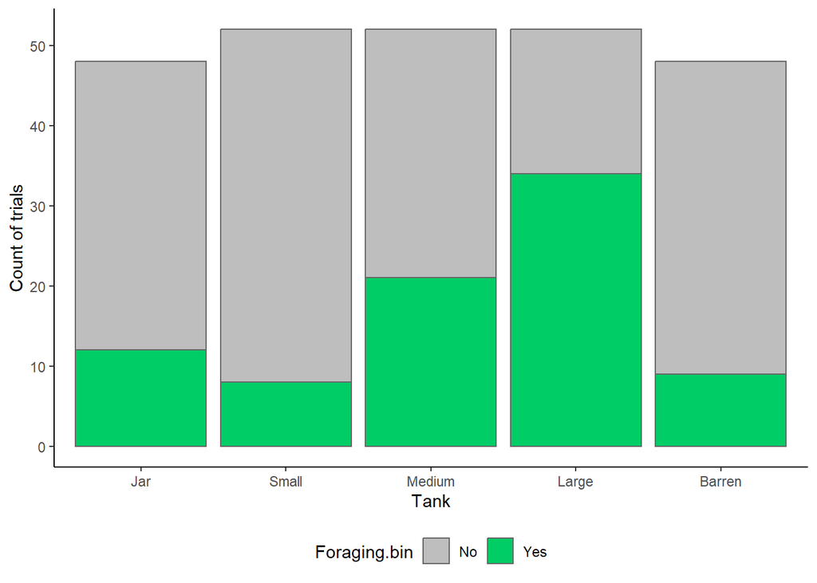

```r
plot_var_binary(data, "Foraging.bin")
```

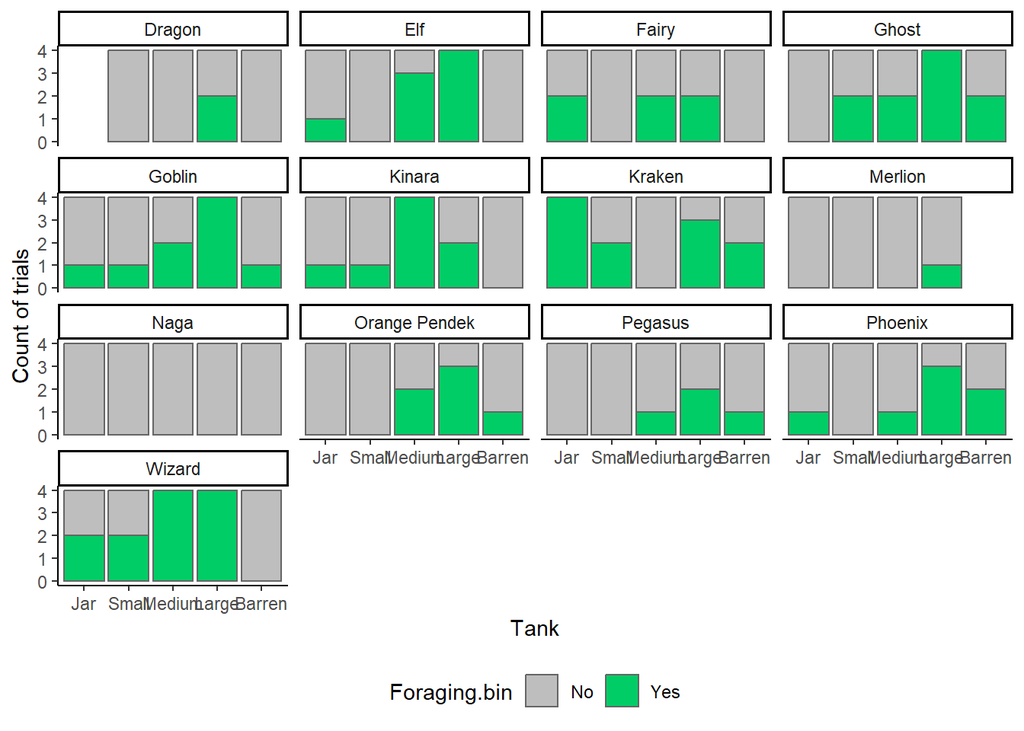

```r
plot_var_binary(data, "Foraging.bin") + facet_wrap(~Fish)
```

**Generalised linear model**

```r
mForaging <- glmmTMB(Foraging.bin ~ Tank + Time + Filter + (1|Fish), data = data, family =binomial)

Anova(mForaging)
```

```
Analysis of Deviance Table (Type II Wald chisquare tests)

Response: Foraging.bin
         Chisq Df Pr(>Chisq)
Tank   32.8992  4  1.253e-06 ***
Time    1.8103  3     0.6127
Filter  0.8031  1     0.3702
---
Signif. codes:  0 '***' 0.001 '**' 0.01 '*' 0.05 '.' 0.1 ' ' 1
```

```r
calc_contrasts_bin(mForaging)
```

```
         contrast odds.ratio   SE  df null z.ratio p.value asymp.LCL asymp.UCL
1    jar_vs_small       1.88 1.03 Inf    1    1.15   0.251     0.428     8.250
2   jar_vs_medium       0.29 0.17 Inf    1   -2.07   0.078     0.056     1.459
3    jar_vs_large       0.08 0.05 Inf    1   -3.97  <0.001     0.014     0.437
4 small_vs_medium       0.15 0.10 Inf    1   -2.90   0.015     0.027     0.875
5  small_vs_large       0.04 0.03 Inf    1   -4.63  <0.001     0.006     0.262
6 medium_vs_large       0.27 0.13 Inf    1   -2.79   0.016     0.076     0.952
7 large_vs_barren      14.64 7.98 Inf    1    4.92  <0.001     3.378    63.486
```

```r
# example of differences between Jar and Large
1/0.08
```

```
[1] 12.5
```

```r
## Upper CI
1/0.014
```

```
[1] 71.42857
```

```r
## Lower CI
1/0.437
```

```
[1] 2.28833
```

Effect of Tank.

As a reminder, an odds.ratio < 1 between tank X vs tank Y means the probability of foraging during a trial in tank X is smaller that the probability of foraging during a trial in tank Y. An odd ratio for instance of 0.2 means that a fish is (1 / 0.2) = five times more likely to forage during a trial in tank Y than in Tank X. If we imagine 5 trials, fish will forage on average during 1 trial out of 5 in Tank X whereas fish will forage on average during 5 trials out of 5 in Tank Y.

- Tank. Fish were more likely to forage during a trial in Large compared to Jar, Small and Medium. Again in accordance with the PCA and the results of Swimming and Resting. Fish in Large were on average 13 times [CI 2, 71] more likely to forage during a trial than fish in Jar, 25 times [CI 4, 166] than fish in Small, and 4 times [CI 1, 13] than fish in Medium. In addition, fish were 15 times [CI 3, 63] more likely to forage during a trial in Large than Barren. In accordance with the PCA and the results of Swimming. This time, there was also a significant difference between small and medium.

**Diagnosis**

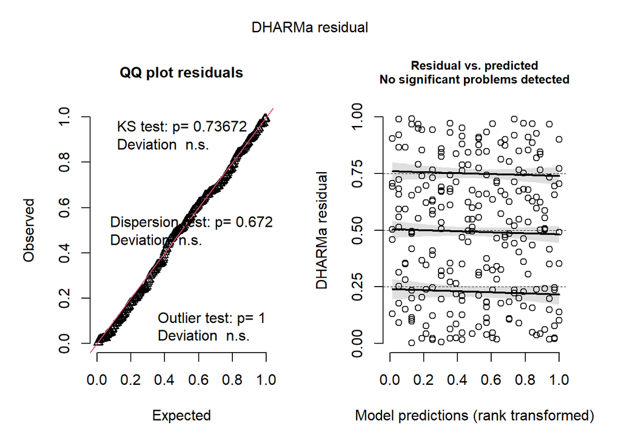

```r
mForaging_res <- simulateResiduals(mForaging)
plot(mForaging_res)
```

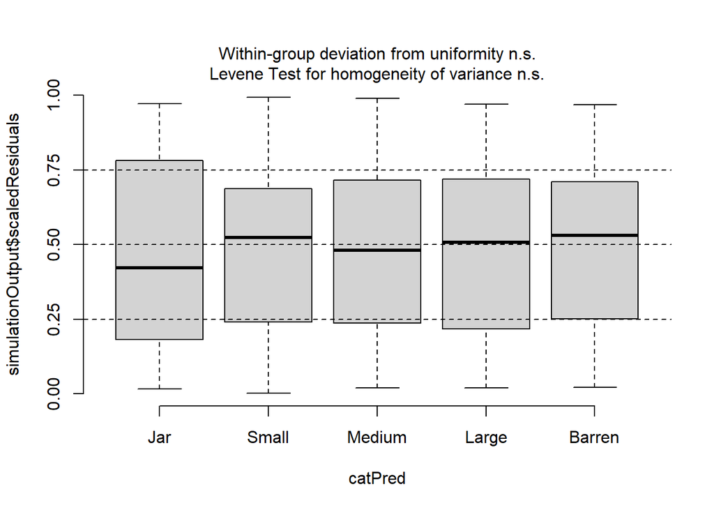

```r
plotResiduals(mForaging_res, form = data$Tank)
```

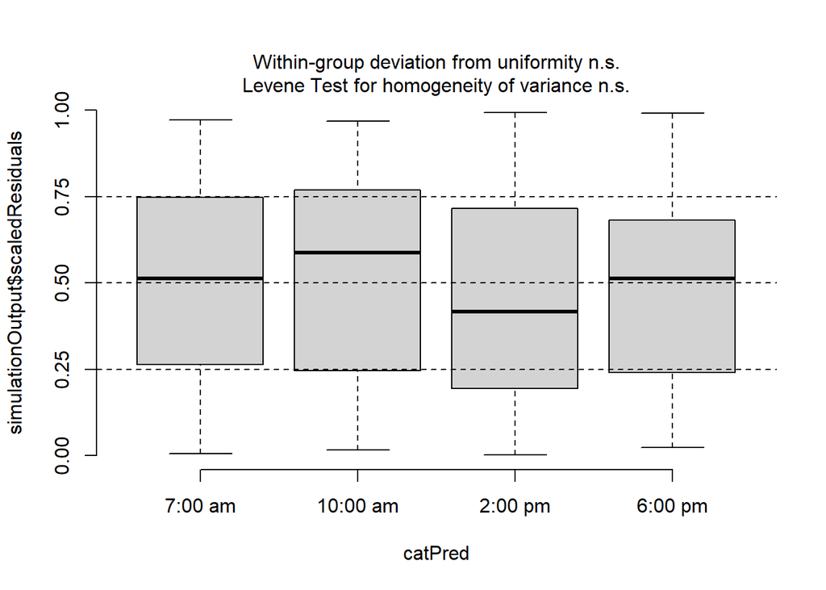

```r
plotResiduals(mForaging_res, form = data$Time)
```

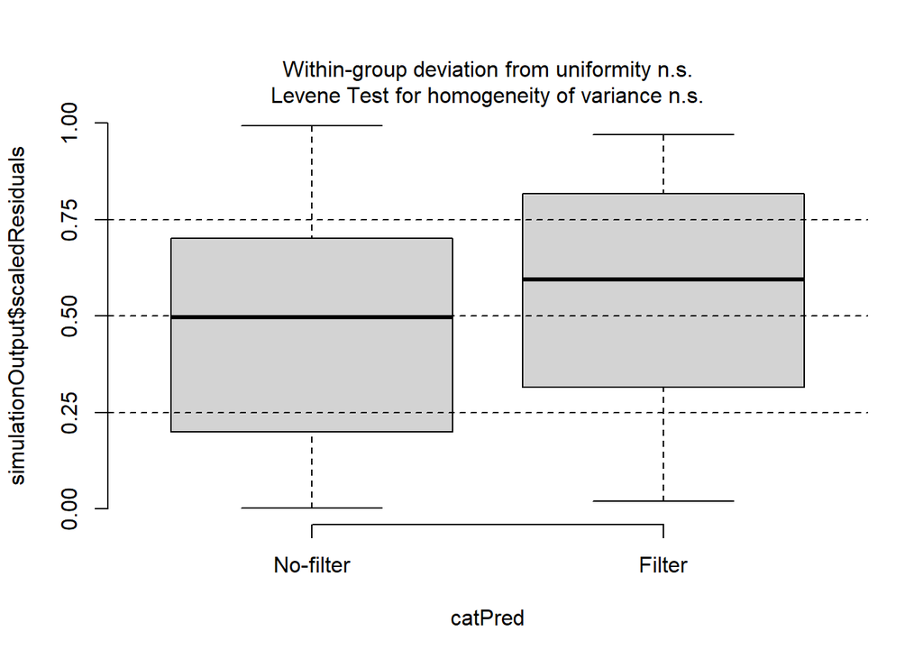

```r
plotResiduals(mForaging_res, form = data$Filter)
```

The model seems good.

**Stereotypic swimming**

**Distribution**

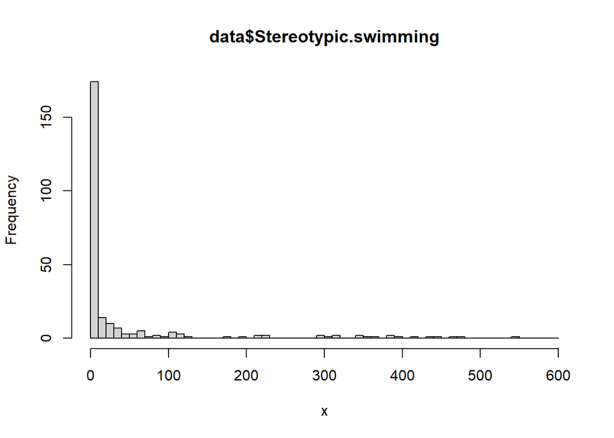

```r
hist1(data$Stereotypic.swimming)
```

```r
table(data$Stereotypic.swimming==0)
```

```
FALSE  TRUE
   80   172
```

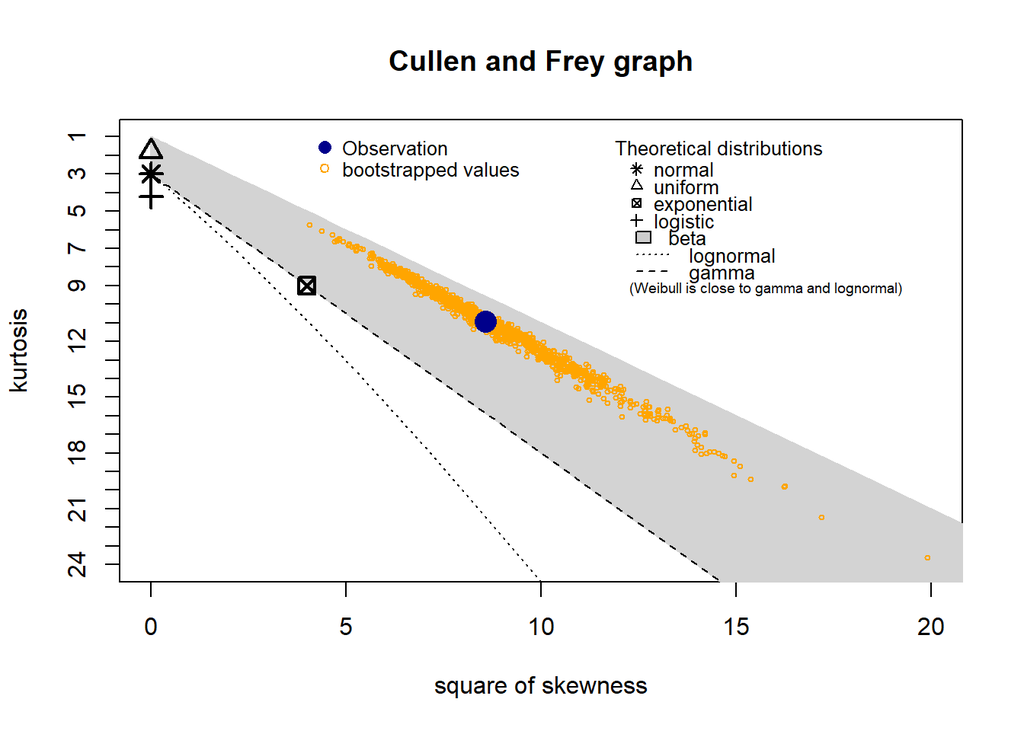

```r
descdist(data$Stereotypic.swimming, boot = 1000, print = FALSE)
```

Idem Foraging. Analysis as binary variable if the fish performs stereotypic swimming during a trial or not.

**Plot**

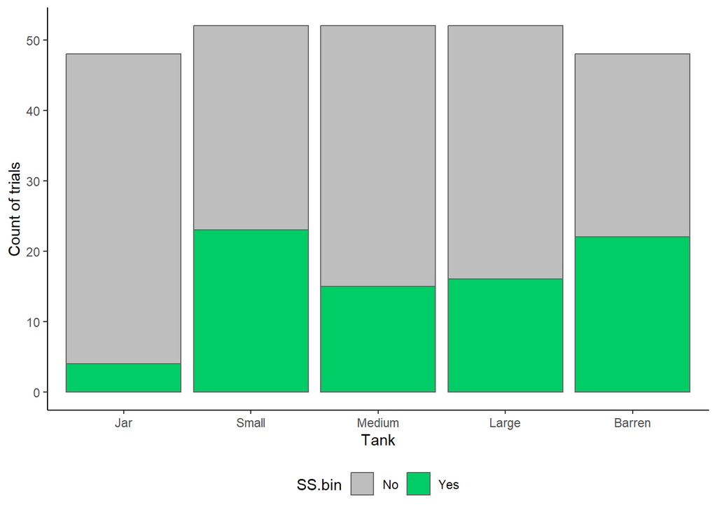

```r
plot_var_binary(data, "SS.bin")
```

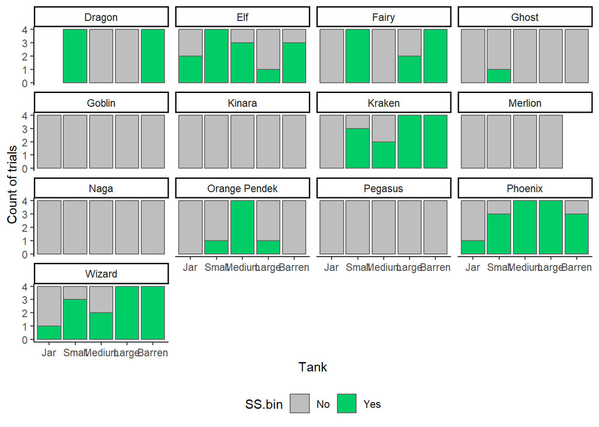

```r
plot_var_binary(data, "SS.bin") + facet_wrap(~Fish)
```

Huge variability between fish as always. Some fish never performed stereotypic swimming while some in all tanks.

**Generalised linear model**

```r
mSS <- glmmTMB(SS.bin ~ Tank + Time + Filter + (1|Fish), data = data, family =binomial)

Anova(mSS)
```

```
Analysis of Deviance Table (Type II Wald chisquare tests)

Response: SS.bin
         Chisq Df Pr(>Chisq)
Tank   24.6257  4  5.982e-05 ***
Time    3.0947  3     0.3773
Filter  1.1698  1     0.2795
---
Signif. codes:  0 '***' 0.001 '**' 0.01 '*' 0.05 '.' 0.1 ' ' 1
```

```r
calc_contrasts_bin(mSS)
```

```
         contrast odds.ratio   SE  df null z.ratio p.value asymp.LCL asymp.UCL
1    jar_vs_small       0.03 0.02 Inf    1   -4.56  <0.001     0.003     0.229
2   jar_vs_medium       0.22 0.21 Inf    1   -1.59   0.284     0.016     2.880
3    jar_vs_large       0.18 0.18 Inf    1   -1.77   0.284     0.014     2.417
4 small_vs_medium       7.87 6.78 Inf    1    2.39   0.100     0.775    79.810
5  small_vs_large       6.60 5.65 Inf    1    2.20   0.138     0.660    66.078
6 medium_vs_large       0.84 0.50 Inf    1   -0.30   0.767     0.171     4.130
7 large_vs_barren       0.32 0.20 Inf    1   -1.80   0.284     0.060     1.743
```

Effect of Tank.

- Tank. Jar were less likely to perform stereotypic swimming during a trial than Small/Medium/Large but only significant between Jar and Small. Fish in Small were 33 times [CI 4, 333] more likely to perform stereotypic swimming during a trial than fish in Jar.

**Diagnosis**

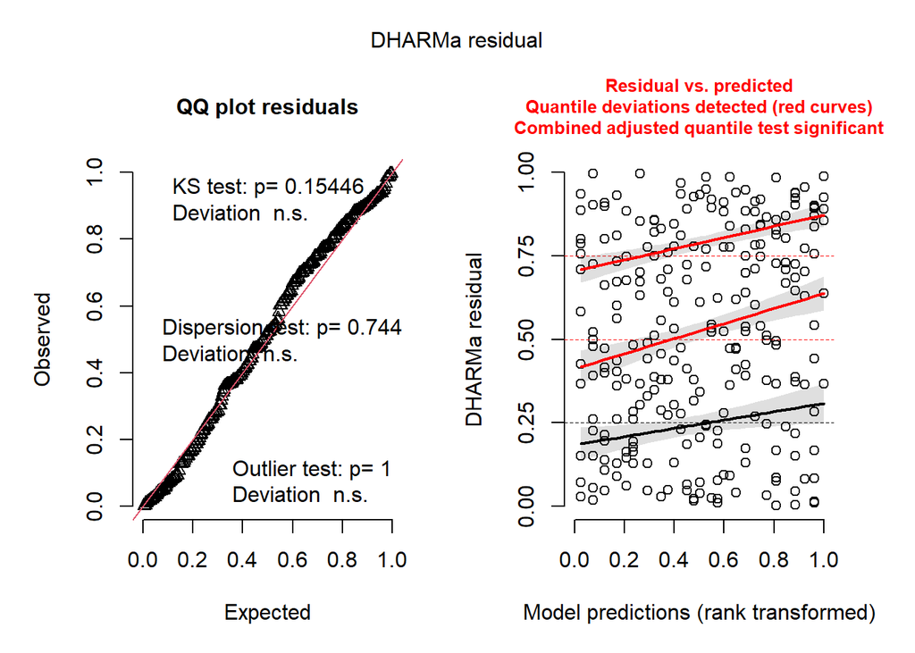

```r
mSS_res <- simulateResiduals(mSS)
plot(mSS_res)
```

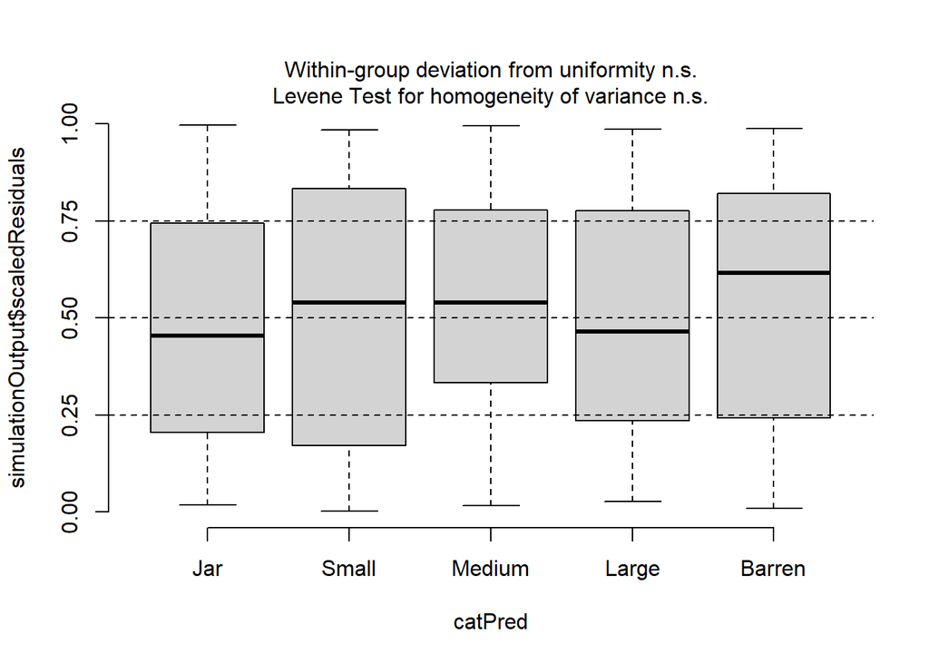

```r
plotResiduals(mSS_res, form = data$Tank)
```

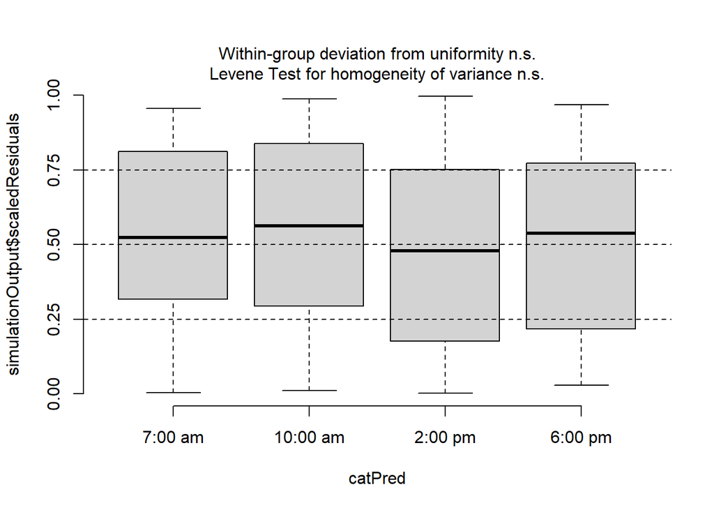

```r
plotResiduals(mSS_res, form = data$Time)
```

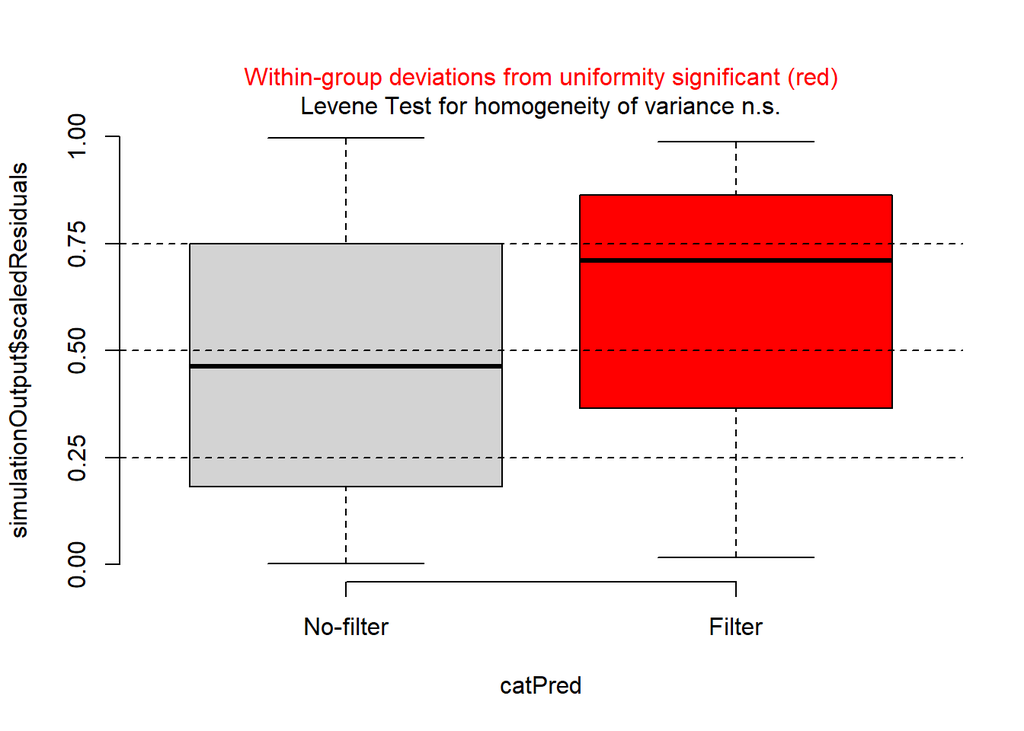

```r
plotResiduals(mSS_res, form = data$Filter)
```

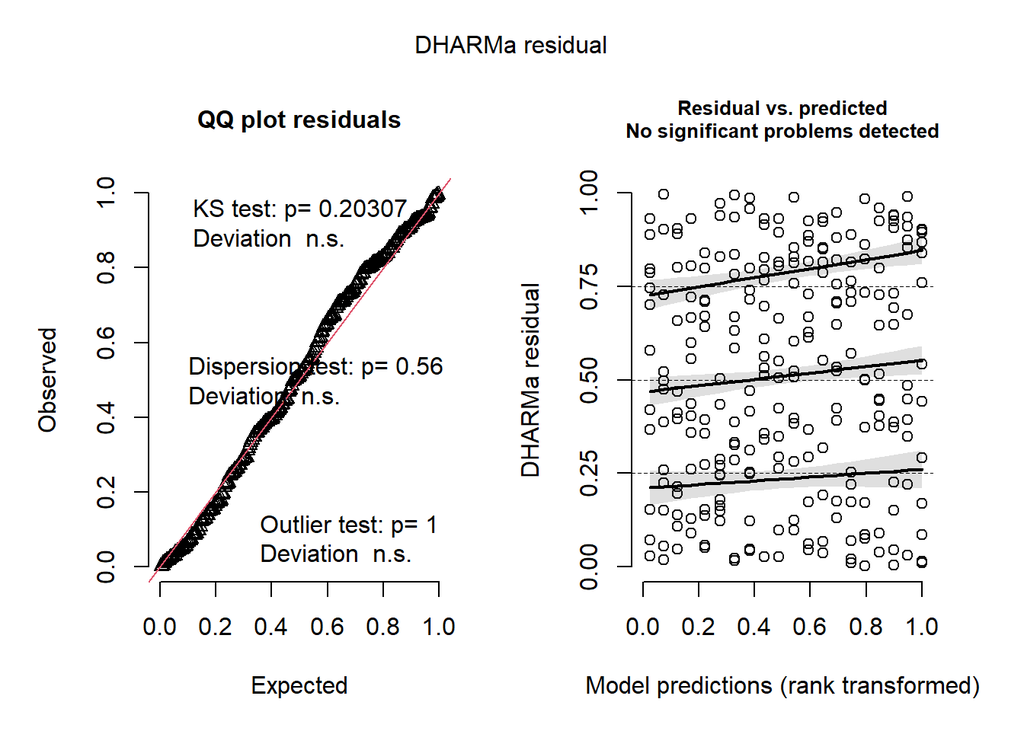

```r
# Problem with Filter, I retried the model without Filter
mSS2 <- glmmTMB(SS.bin ~ Tank + Time + (1|Fish), data = data, family =binomial)
plot(simulateResiduals(mSS2))
```

It is expected to have a problem with filter as there are more than twice more trials without filter than with filter. No problem when removing Filter from the model. The model seems good.

**Stereotypic types**

Just a plot with the type of stereotypic swimming depending on the tank. To stick with the analysis, it is a count (count = 1 if the fish performs a certain type of stereotypic swimming during a trial).

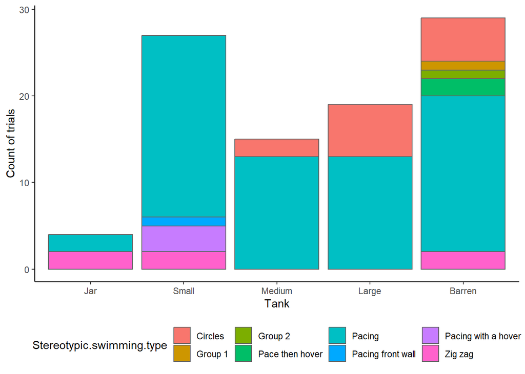

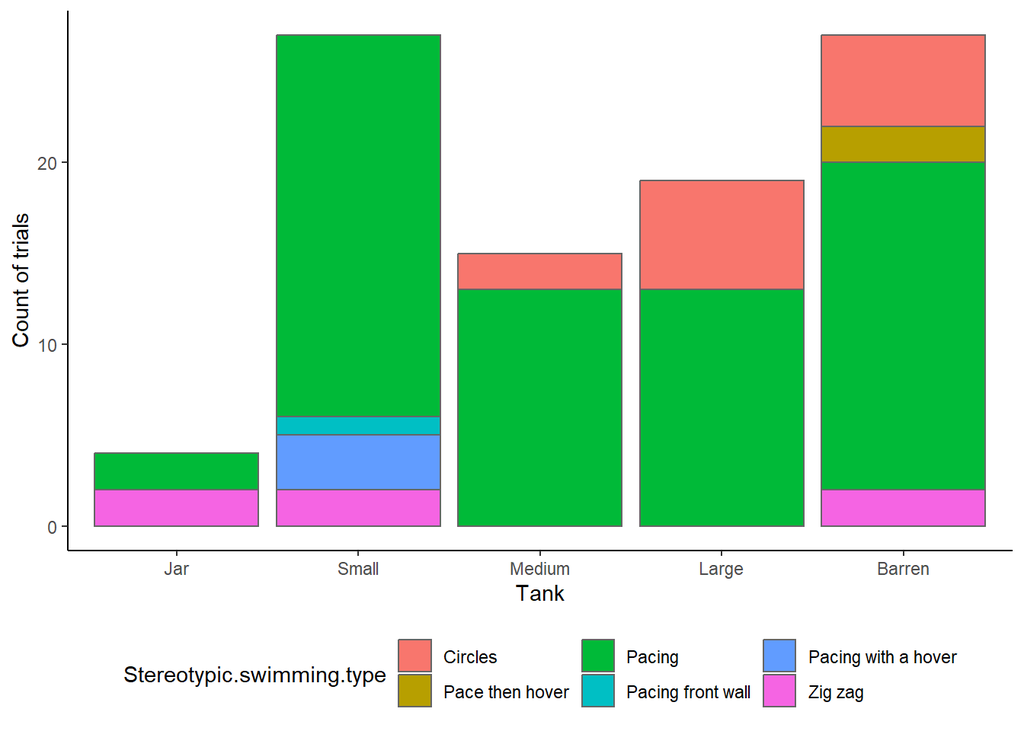

Problem in the data: what is “Group1” and “Group2”? Check the data.

Similarly with the types of Interaction with Surface, I suggest grouping different types of stereotypic swimming together to make it clearer.

It seems that there are not differences between tanks. Just circles seem specific to larger tanks (Medium/Large/Barren).

I did not plot the place where the stereotypic swimming happens. Tell me if you need it.

**Stereotypic Swimming repetitions**

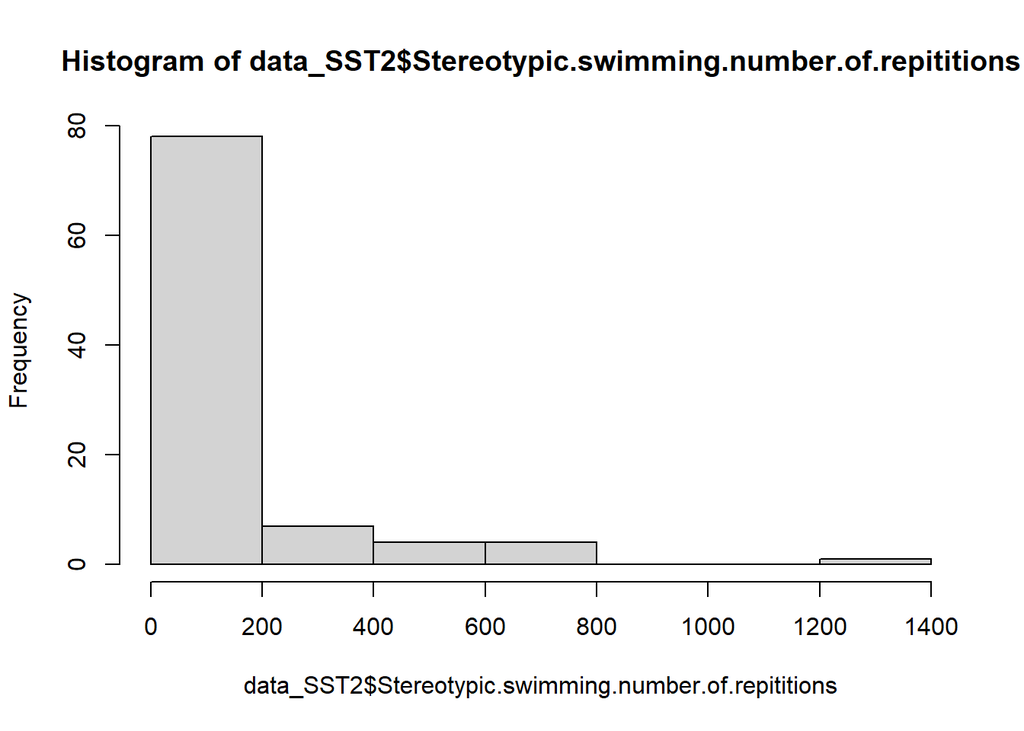

```
     Tank          Fish     Time Stereotypic.swimming.type Nb.rep
1     Jar           Elf  7:00 am                   Zig zag      4
2     Jar           Elf  6:00 pm                   Zig zag      6
3     Jar       Phoenix 10:00 am                    Pacing      3
4     Jar        Wizard  2:00 pm                    Pacing      7
5   Small        Dragon  7:00 am                    Pacing    328
6   Small        Dragon 10:00 am                    Pacing     76
7   Small        Dragon  2:00 pm                    Pacing     20
8   Small        Dragon  6:00 pm                    Pacing      8
9   Small        Dragon  6:00 pm         Pacing front wall      8
10  Small           Elf  7:00 am                    Pacing     15
11  Small           Elf 10:00 am                    Pacing     15
12  Small           Elf  2:00 pm                    Pacing    109
13  Small           Elf  6:00 pm                    Pacing     25
14  Small         Fairy  7:00 am                    Pacing    234
```

[output cut: 80 more lines]

I don’t think there are enough repetitions to really say something about the number of repetitions. The number of repetitions seems pretty unique to a fish in a certain tank. I don’t see a pattern depending on the tank. The interesting thing is that the stereotypic swimming seemed consistent in a tank for a fish (most or all trials of that day with stereotypic swimming). I don’t know if it is possible to calculate the repeatability of a binomial glm, but it would be interesting.

**Hovering**

**Distribution**

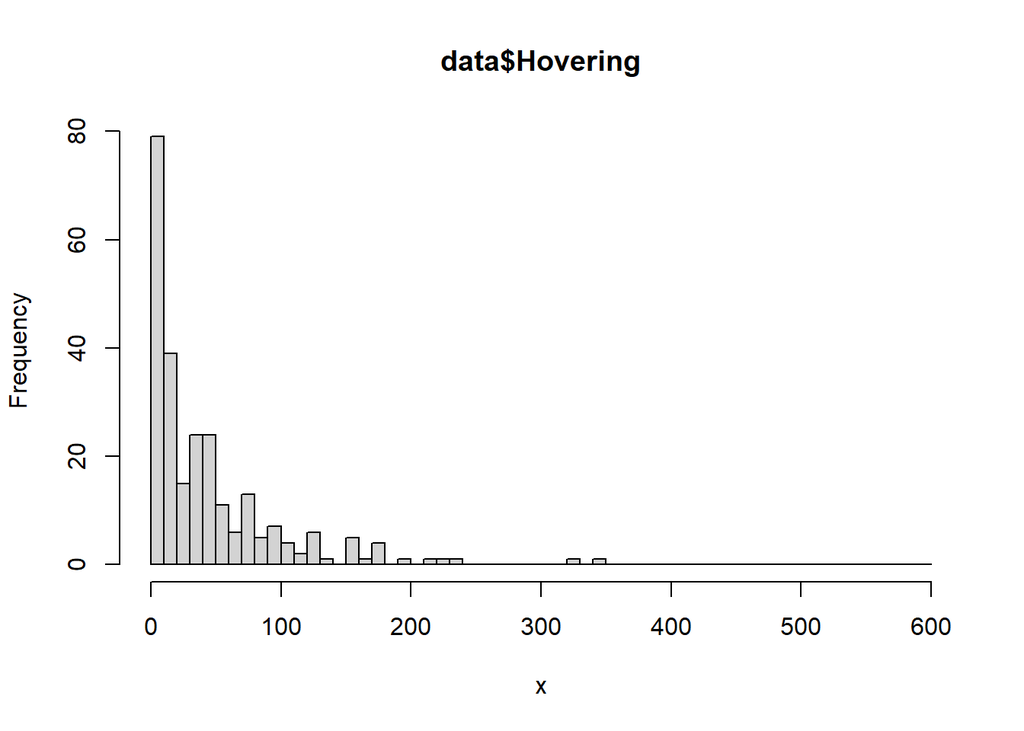

```r
hist1(data$Hovering)
```

```r
table(data$Hovering==0)
```

```
FALSE  TRUE
  204    48
```

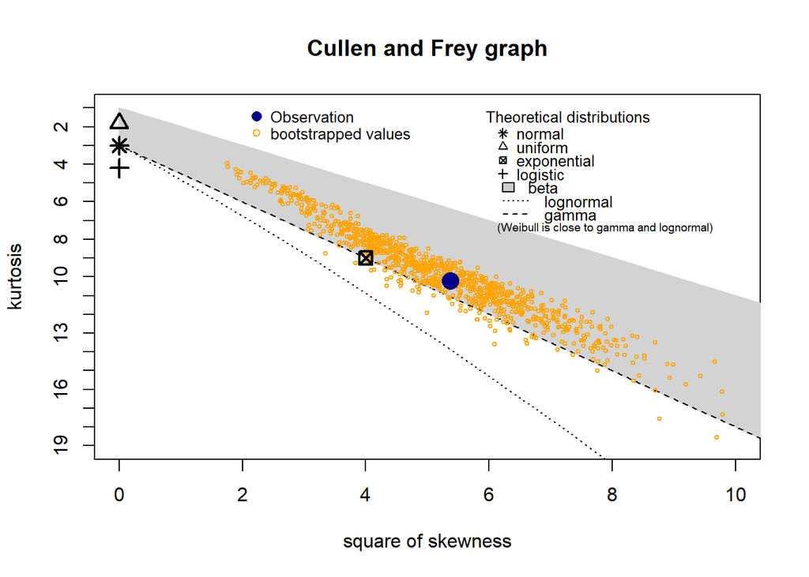

```r
descdist(data$Hovering, boot = 1000, print = FALSE)
```

```r
quantile(data$Hovering)
```

```
    0%    25%    50%    75%   100%
  0.00   6.01  23.71  56.21 344.27
```

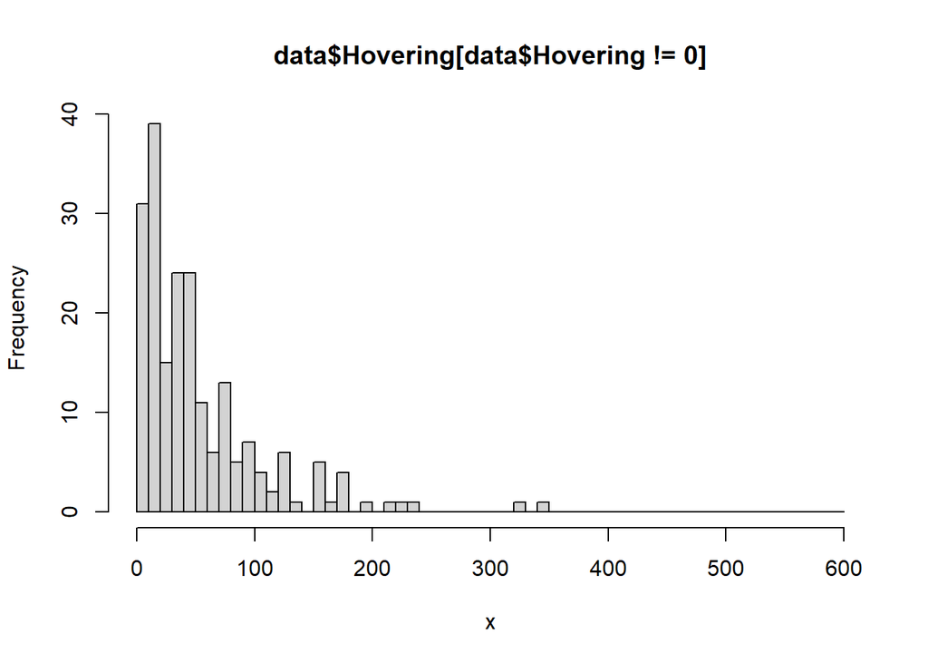

```r
hist1(data$Hovering[data$Hovering!=0])
```

Even if there are less zeros than Foraging or Stereotypic Swimming, it is not a normal distribution. Even after removing the zeros, the distribution does not look like normal. Unless having a better idea, Hovering will be analysed as a binary variable.

**Plot**

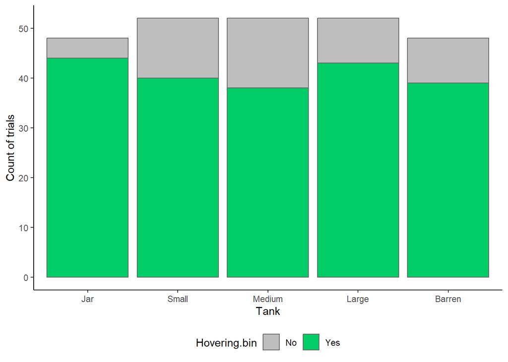

```r
plot_var_binary(data, "Hovering.bin")
```

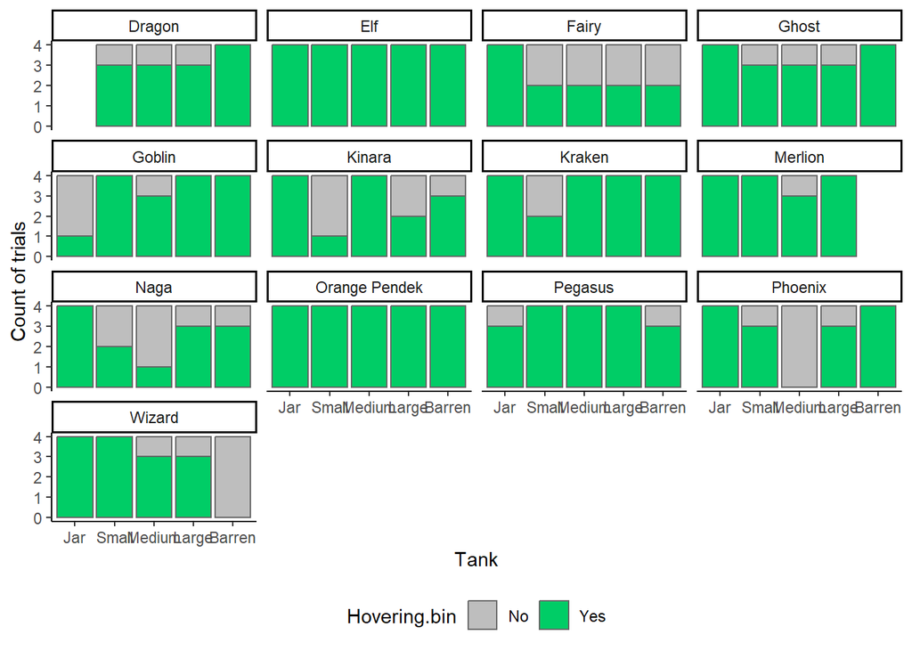

```r
plot_var_binary(data, "Hovering.bin") + facet_wrap(~Fish)
```

**Generalised linear model**

```r
mHovering <- glmmTMB(Hovering.bin ~ Tank + Time + Filter + (1|Fish), data = data, family =binomial)

Anova(mHovering)
```

```
Analysis of Deviance Table (Type II Wald chisquare tests)

Response: Hovering.bin
        Chisq Df Pr(>Chisq)
Tank   6.8189  4    0.14578
Time   9.3478  3    0.02501 *
Filter 4.3176  1    0.03772 *
---
Signif. codes:  0 '***' 0.001 '**' 0.01 '*' 0.05 '.' 0.1 ' ' 1
```

```r
emmeans(mHovering, ~ Time, type = "response")
```

```
 Time      prob     SE  df asymp.LCL asymp.UCL
 7:00 am  0.917 0.0398 Inf     0.798     0.969
 10:00 am 0.870 0.0525 Inf     0.729     0.943
 2:00 pm  0.728 0.0786 Inf     0.551     0.854
 6:00 pm  0.747 0.0760 Inf     0.573     0.866

Results are averaged over the levels of: Tank, Filter
Confidence level used: 0.95
Intervals are back-transformed from the logit scale
```

```r
emmeans(mHovering, ~ Filter, type = "response")
```

```
 Filter     prob     SE  df asymp.LCL asymp.UCL
 No-filter 0.900 0.0343 Inf     0.810     0.950
 Filter    0.729 0.0933 Inf     0.516     0.872

Results are averaged over the levels of: Tank, Time
Confidence level used: 0.95
Intervals are back-transformed from the logit scale
```

No effect of Tank, only an effect of Time and filter

- Time. Fish were less likely to hover in the afternoon.
- Filter. Fish were less likely to hover with a filter in their tank.

**Diagnosis**

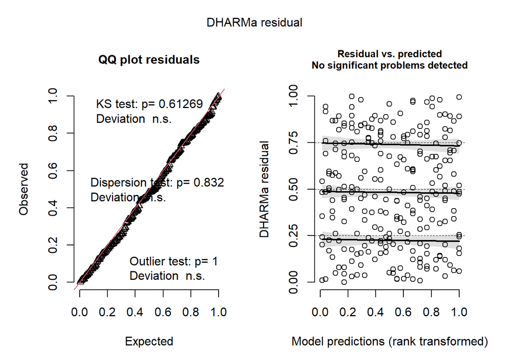

```r
mHovering_res <- simulateResiduals(mHovering)
plot(mHovering_res)
```

The model seems good.

**Hovering place**

Just a plot with where the fish hovers at the different places depending on the tank. To stick with the analysis, it is a count (count = 1 if the fish hovers in this place during a trial).

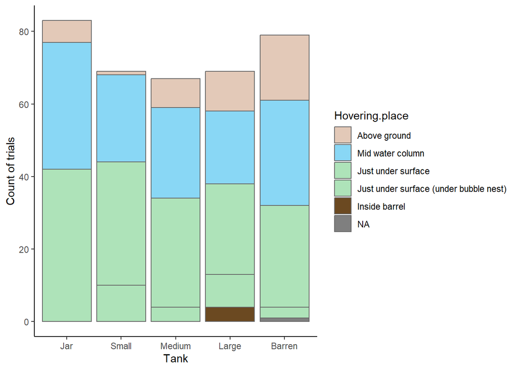

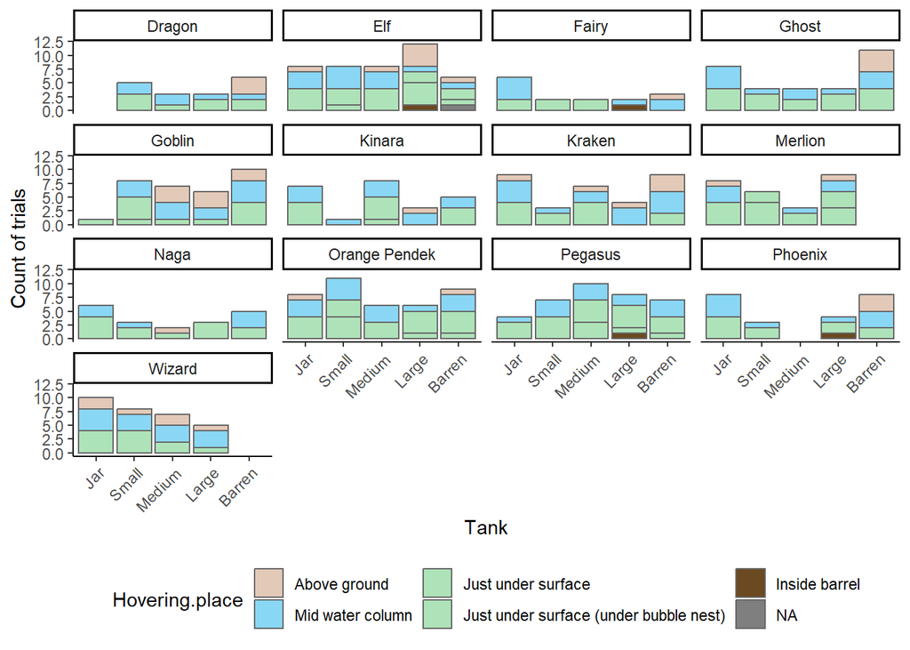

Fish used different places for hovering in all tanks.

**Interaction with Surface**

**Distribution**

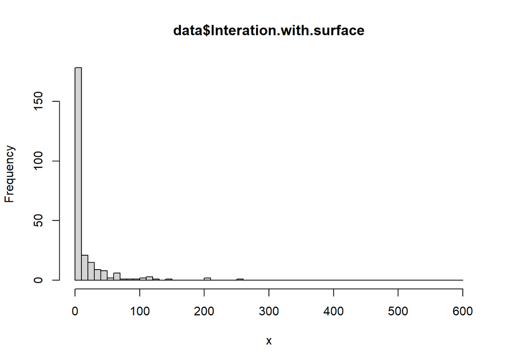

```r
hist1(data$Interation.with.surface)
```

```r
table(data$Interation.with.surface==0)
```

```
FALSE  TRUE
  127   125
```

Idem analysis binary generalised linear models.

**Plot**

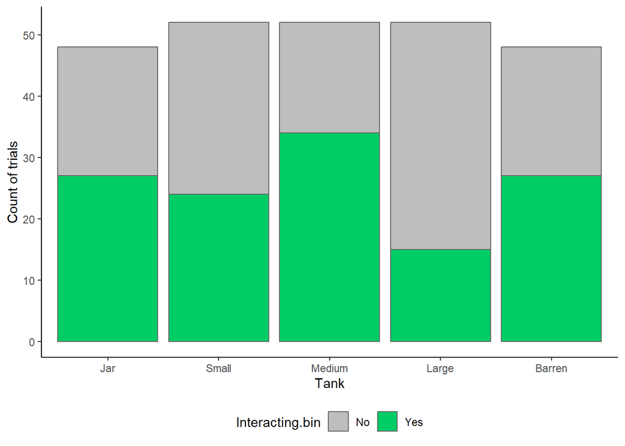

```r
plot_var_binary(data, "Interacting.bin")
```

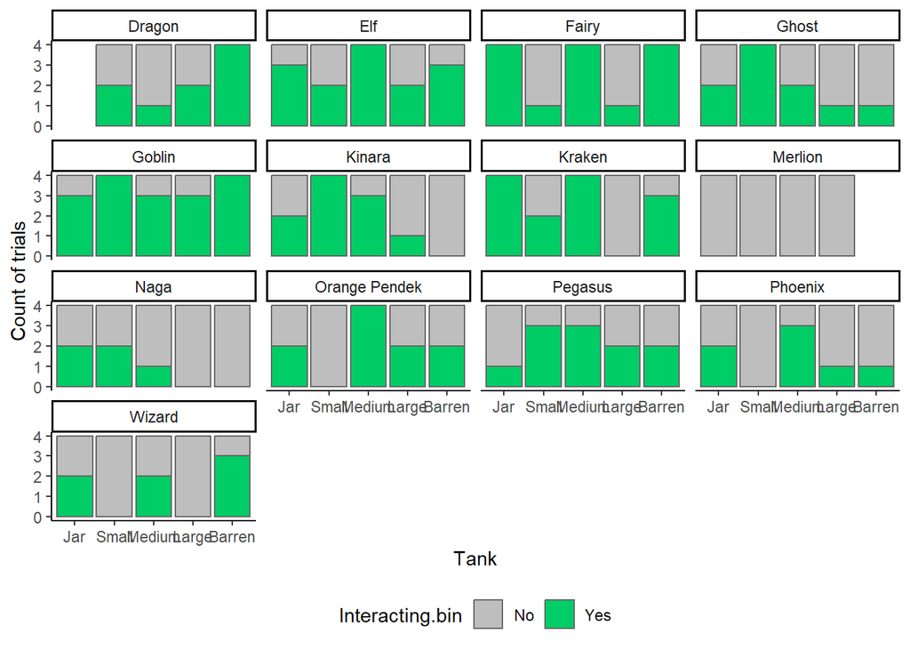

```r
plot_var_binary(data, "Interacting.bin") + facet_wrap(~Fish)
```

**Generalised linear model**

```r
mInteracting <- glmmTMB(Interacting.bin ~ Tank + Time + Filter + (1|Fish), data = data, family =binomial)

Anova(mInteracting)
```

```
Analysis of Deviance Table (Type II Wald chisquare tests)

Response: Interacting.bin
         Chisq Df Pr(>Chisq)
Tank   17.1723  4   0.001789 **
Time    5.0268  3   0.169846
Filter  0.0876  1   0.767253
---
Signif. codes:  0 '***' 0.001 '**' 0.01 '*' 0.05 '.' 0.1 ' ' 1
```

```r
calc_contrasts_bin(mInteracting)
```

```
         contrast odds.ratio   SE  df null z.ratio p.value asymp.LCL asymp.UCL
1    jar_vs_small       1.68 0.75 Inf    1    1.15   0.497     0.503     5.580
2   jar_vs_medium       0.69 0.35 Inf    1   -0.72   0.497     0.174     2.748
3    jar_vs_large       4.39 2.32 Inf    1    2.80   0.030     1.061    18.167
4 small_vs_medium       0.41 0.21 Inf    1   -1.74   0.251     0.105     1.625
5  small_vs_large       2.62 1.36 Inf    1    1.86   0.251     0.651    10.547
6 medium_vs_large       6.35 3.00 Inf    1    3.92  <0.001     1.783    22.628
7 large_vs_barren       0.30 0.14 Inf    1   -2.66   0.039     0.086     1.012
```

Effect of Tank.

**Diagnosis**

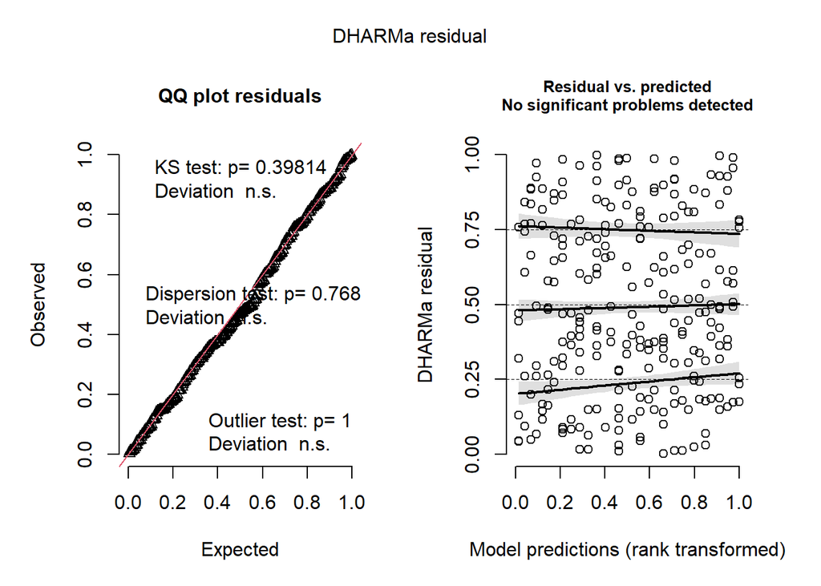

```r
mInteracting_res <- simulateResiduals(mInteracting)
plot(mInteracting_res)
```

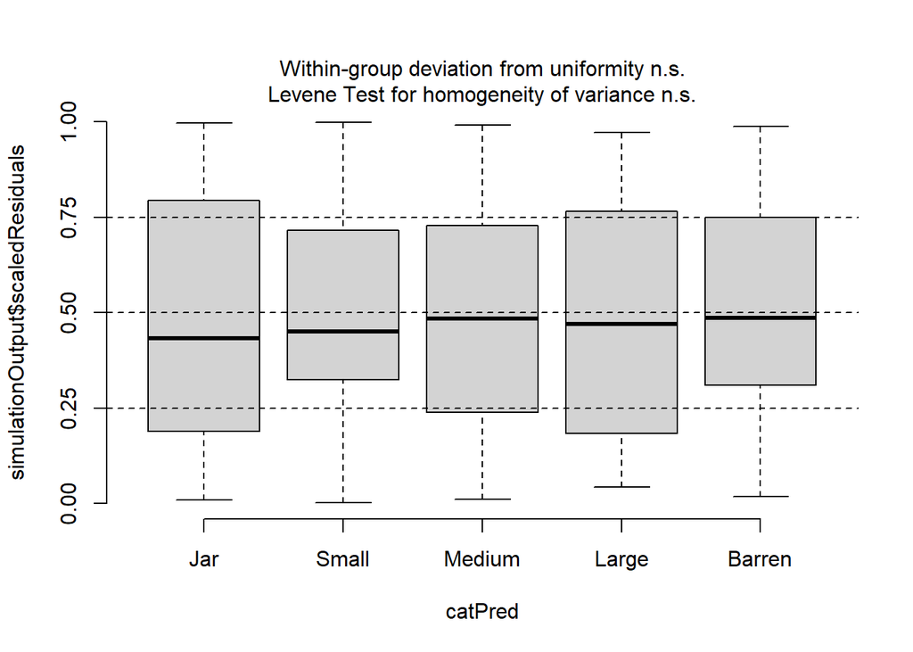

```r
plotResiduals(mInteracting_res, form = data$Tank)
```

The model seems good.

**Interacting types**

Just a plot with the type of interaction depending on the tank. To stick with the analysis, it is a count (count = 1 if the fish performs a certain type of interaction with surface during a trial).

[figure not shown]

Idem, it would be nice to group together certain types of interaction to make it clearer.

**Nest.building**

**Distribution**

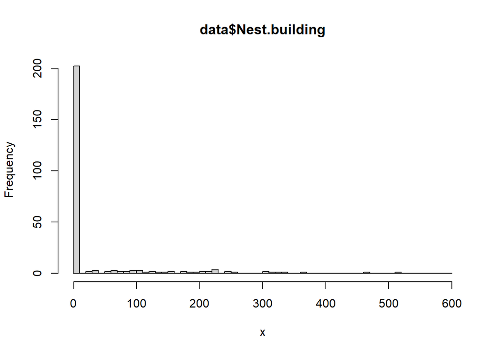

```r
hist1(data$Nest.building)
```

```r
table(data$Nest.building==0)
```

```
FALSE  TRUE
   51   201
```

There are 1 trial out of 5 where there was nest building. Analysis binary generalised model.

**Plot**

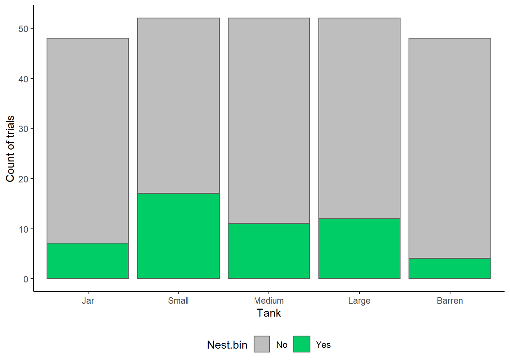

```r
plot_var_binary(data, "Nest.bin")
```

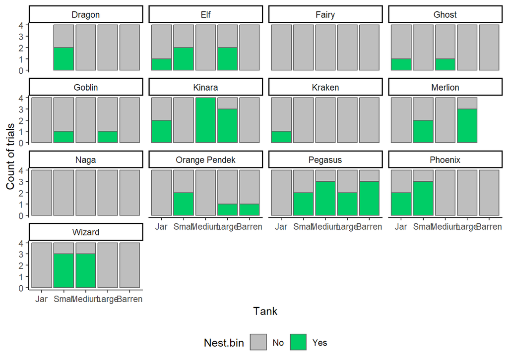

```r
plot_var_binary(data, "Nest.bin") + facet_wrap(~Fish)
```

**Generalised linear model**

```r
mNest <- glmmTMB(Nest.bin ~ Tank + Time + Filter + (1|Fish), data = data, family =binomial)

Anova(mNest)
```

```
Analysis of Deviance Table (Type II Wald chisquare tests)

Response: Nest.bin
         Chisq Df Pr(>Chisq)
Tank   10.1022  4   0.038741 *
Time    7.1655  3   0.066804 .
Filter 10.3912  1   0.001266 **
---
Signif. codes:  0 '***' 0.001 '**' 0.01 '*' 0.05 '.' 0.1 ' ' 1
```

```r
calc_contrasts_bin(mNest)
```

```
         contrast odds.ratio   SE  df null z.ratio p.value asymp.LCL asymp.UCL
1    jar_vs_small       0.29 0.16 Inf    1   -2.24   0.150     0.065     1.283
2   jar_vs_medium       0.25 0.16 Inf    1   -2.15   0.158     0.046     1.410
3    jar_vs_large       0.22 0.14 Inf    1   -2.40   0.116     0.040     1.205
4 small_vs_medium       0.89 0.50 Inf    1   -0.22  >0.999     0.196     3.992
5  small_vs_large       0.76 0.42 Inf    1   -0.49  >0.999     0.171     3.398
6 medium_vs_large       0.86 0.47 Inf    1   -0.27  >0.999     0.196     3.770
7 large_vs_barren       4.17 2.90 Inf    1    2.05   0.162     0.639    27.143
```

```r
emmeans(mNest, ~ Filter, type = "response")
```

```
 Filter      prob     SE  df asymp.LCL asymp.UCL
 No-filter 0.2081 0.0621 Inf   0.11154    0.3549
 Filter    0.0234 0.0170 Inf   0.00552    0.0935

Results are averaged over the levels of: Tank, Time
Confidence level used: 0.95
Intervals are back-transformed from the logit scale
```

Effect of Tank and Filter. + Tank. Despite a significant effect of Tank, no contrasts were statistically significant. This is usual when you have a weakly significant fixed effect of a factor (0.01 < p-value < 0.05) which has a lot of different levels. In terms of trend, fish in Jar seemed less likely to build a nest compared to Small/Medium/Large. In addition, fish in Barren were less likely to build nest than fish in Large. + Filter. Fish were more likely to build a nest without a filter in their tank.

**Diagnosis**

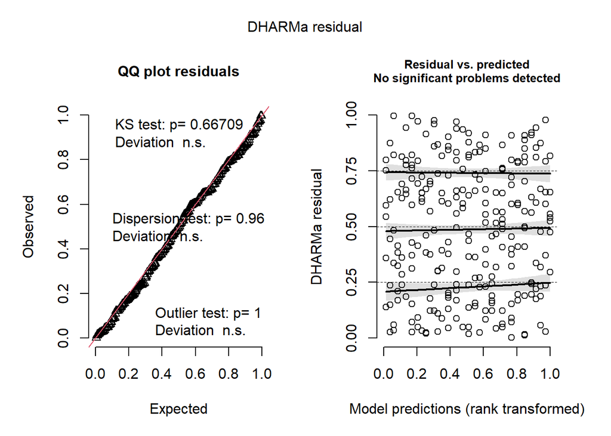

```r
mNest_res <- simulateResiduals(mNest)
plot(mNest_res)
```

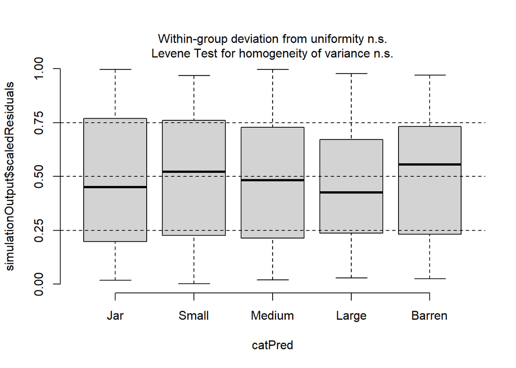

```r
plotResiduals(mNest_res, form = data$Tank)
```

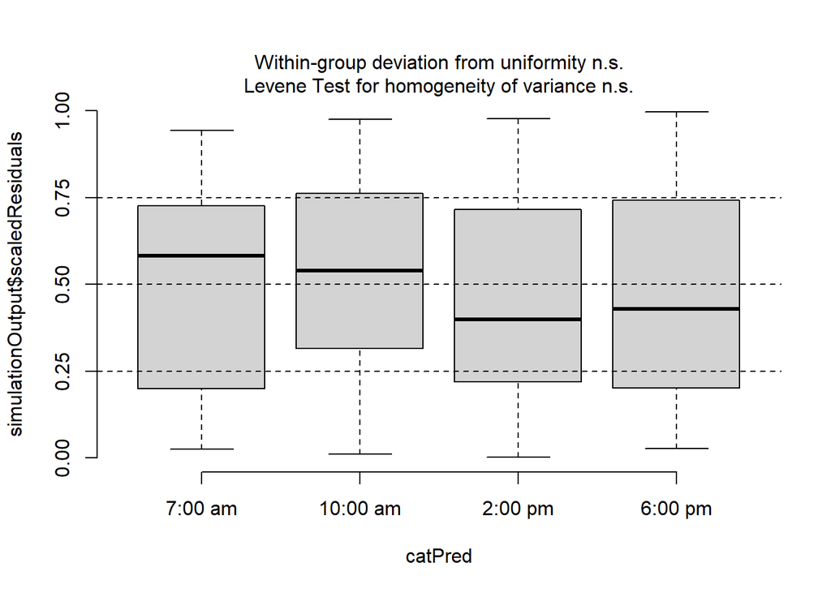

```r
plotResiduals(mNest_res, form = data$Time)
```

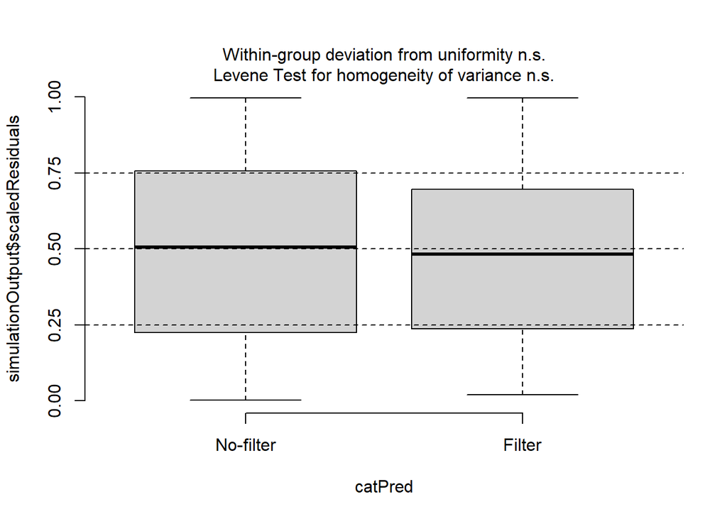

```r
plotResiduals(mNest_res, form = data$Filter)
```

The model seems good.

**Sinking/Floating**

I have analysed Sinking/Floating, but if it were up to me, I would give up this variable in view of the PCA.

**Distribution**

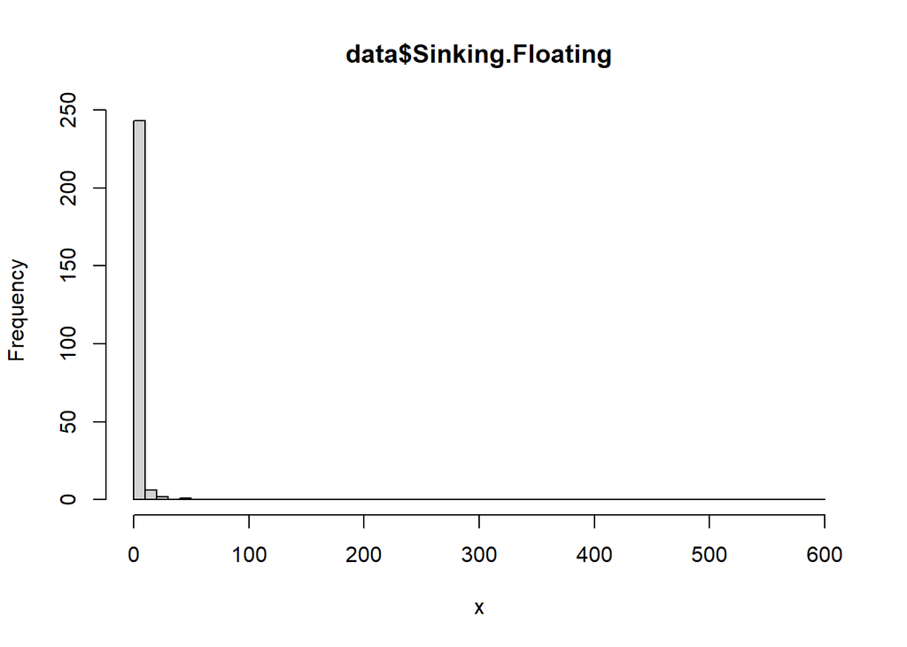

```r
hist1(data$Sinking.Floating)
```

```r
table(data$Sinking.Floating==0)
```

```
FALSE  TRUE
   34   218
```

Many zeros, analysis with a binary generalised linear model.

**Plot**

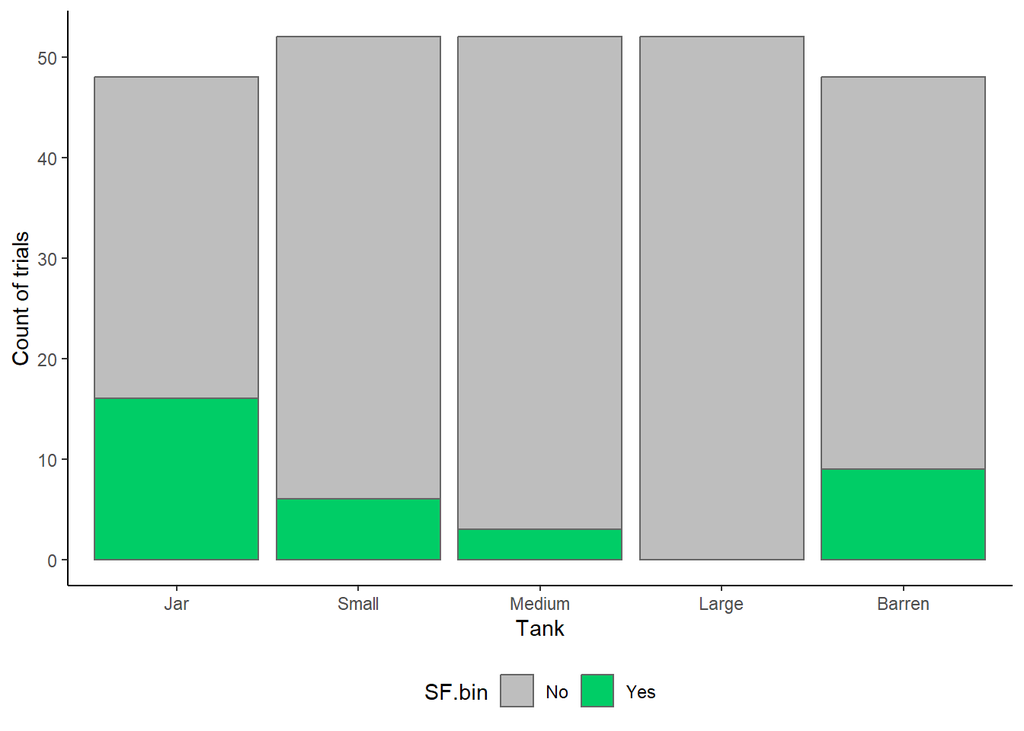

```r
plot_var_binary(data, "SF.bin")
```

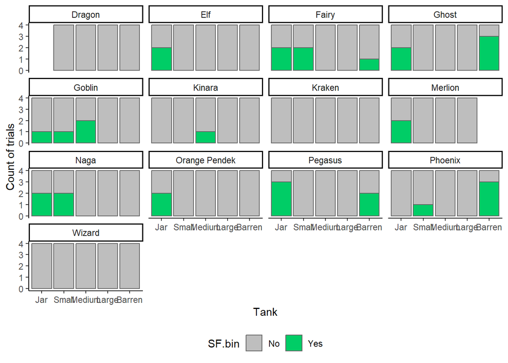

```r
plot_var_binary(data, "SF.bin") + facet_wrap(~Fish)
```

**Generalised linear model**

```r
mSF <- glmmTMB(SF.bin ~ Tank + Time + Filter + (1|Fish), data = data, family =binomial)

Anova(mSF)
```

```
Analysis of Deviance Table (Type II Wald chisquare tests)

Response: SF.bin
         Chisq Df Pr(>Chisq)
Tank   13.3270  4   0.009784 **
Time    2.7140  3   0.437853
Filter  0.8461  1   0.357665
---
Signif. codes:  0 '***' 0.001 '**' 0.01 '*' 0.05 '.' 0.1 ' ' 1
```

```r
calc_contrasts_bin(mSF)
```

```
         contrast    odds.ratio                SE  df null z.ratio p.value
1    jar_vs_small          4.14              2.30 Inf    1    2.56   0.063
2   jar_vs_medium         12.79             10.31 Inf    1    3.16   0.011
3    jar_vs_large 5839608876.91 68600956948043.23 Inf    1    0.00  >0.999
4 small_vs_medium          3.09              2.64 Inf    1    1.32   0.935
5  small_vs_large 1411041026.88 16576241115502.40 Inf    1    0.00  >0.999
6 medium_vs_large  456699541.70  5365089728647.80 Inf    1    0.00  >0.999
7 large_vs_barren          0.00              0.00 Inf    1   -0.00  >0.999
  asymp.LCL asymp.UCL
1     0.929    18.444
2     1.461   111.937
3     0.000       Inf
4     0.310    30.824
5     0.000       Inf
6     0.000       Inf
7     0.000       Inf
```

Effect of Tank.

- Tank. Problem with the calculation of contrast because fish never sinked or floated in Large. Solution 1: don’t include this behavioural type at all in the analysis as it has very little influence based on the PCA. Solution 2: include it anyway and state that the calculation of contrasts and corresponding tests were not possible. Just intepret it qualitatively with no test (Fish were more likely to perform sinking/floating in Jar, then Small and Medium were pretty similar, then Large. Fish in Barren were more likely to perform Sinking/Floating than fish in Large).

**Diagnosis**

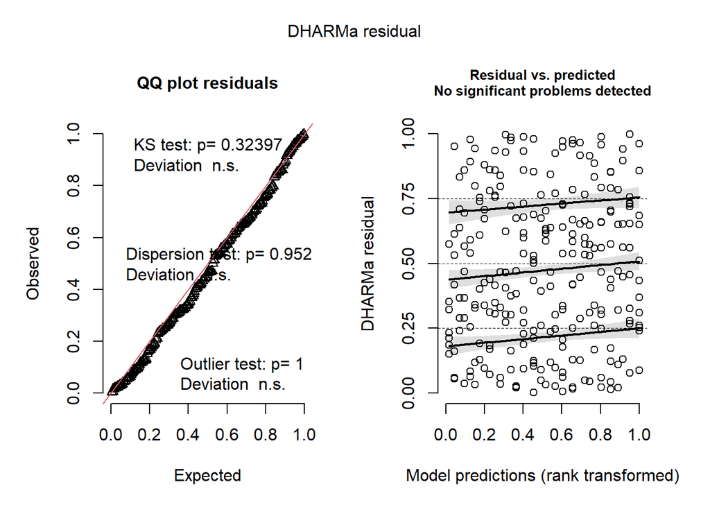

```r
mSF_res <- simulateResiduals(mSF)
plot(mSF_res)
```

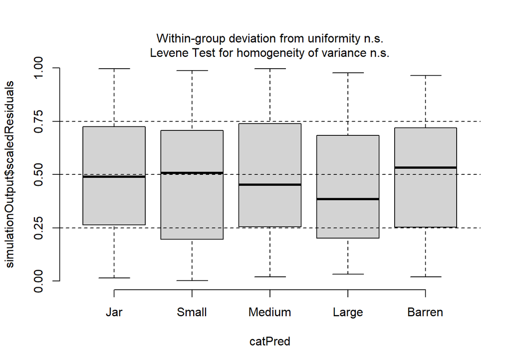

```r
plotResiduals(mSF_res, form = data$Tank)
```

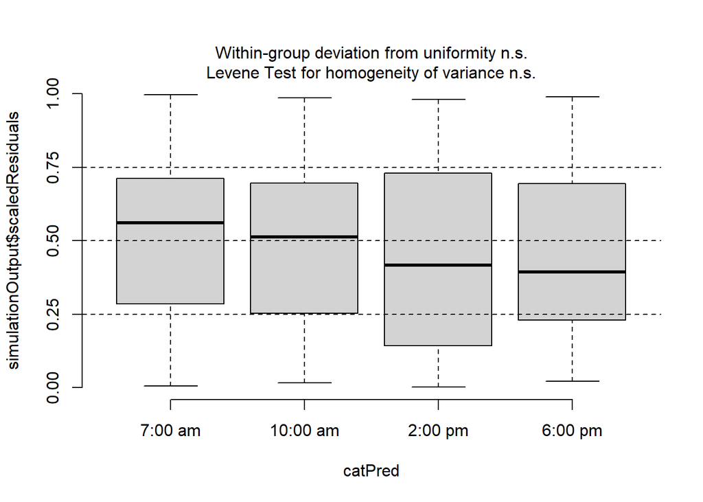

```r
plotResiduals(mSF_res, form = data$Time)
```

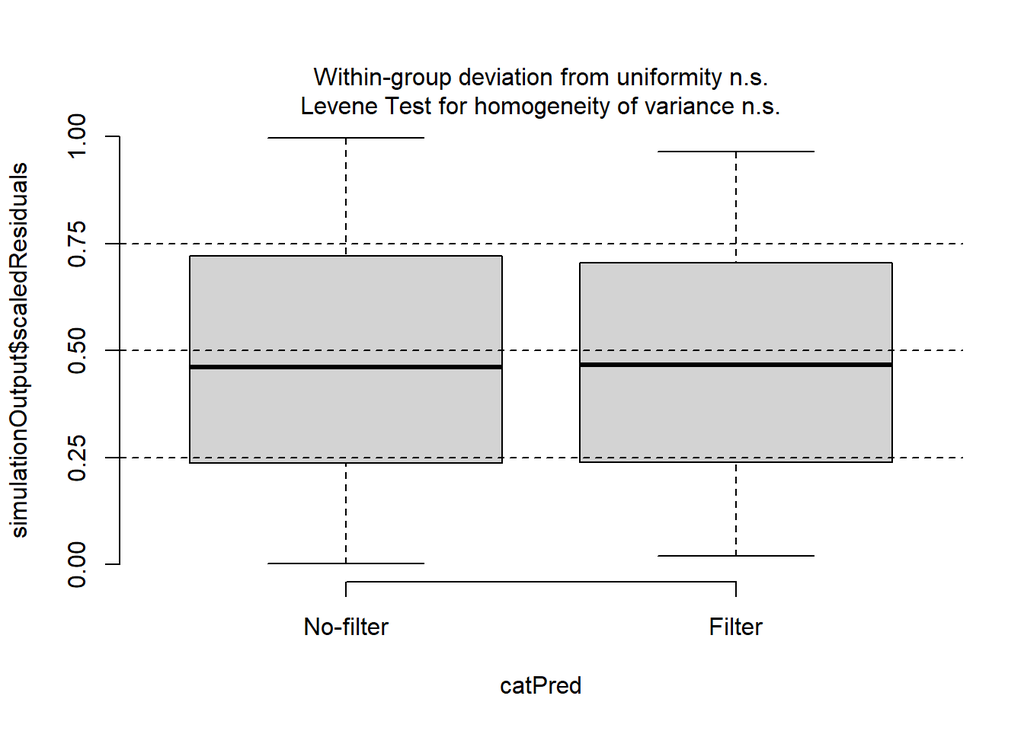

```r
plotResiduals(mSF_res, form = data$Filter)
```

The model seems good.

**Conclusion**

Here how I see the results section.

First, I would include the PCA to show the correlations between variables and to highlight the important variables that contribute to the most of variability in behaviour

Second, I would do a first big table for the results of the anova with the F-value, NumDf, DenDf and associated p-value for the fixed effects Tank, Filter and Time fixed effects. For the generalised mixed models (foraging, stereotypic swimming, etc), it is not the F-value but the Chisq, Df and p-value Foraging, Stereotypic Swimming, etc). For the linear models, I will also include in this big table the results for the random effect (Variance explained by fish, Residual variance and Repeatability). Then, I would put another table with the results of the contrasts between tanks with the contrast estimates, their confidence intervals, the associated t- or z-tests and p-values for readers to have an idea of the size of the difference between treatments. It is worth noting that the confidence intervals are large which is normal considering the number of fish.

Based on the two tables, what we can say first is that there is a effect of the Tank on all behaviours, the tank is there having a big influence on the betta’s behaviour. Then, tt seems that we have three groups for the Jar/Small/Medium/Large

- Jar with less likely to build a nest and less likely to perform stereotypic swimming compared to the others
- Small and Medium
- Large with more time swimming, less time resting, more likely to forage and less likely to interact with the surface

And Large and Barren are two different groups + Barren with less likely to build a nest + Large with more time swimming, more likely to forage and less likely to interact with the surface

Also, I would put something about the fact that each fish behave pretty uniquely.

Tell me if you have any questions or would like to change something.

The only thing I would like to do is to make sure the order in which fish have experienced the different tanks did not have any influence.